# Homework_04

Mustafa Kamal Shahadat

2023-03-23

Loading Required packages

```r
library(tidyverse)
library(dlookr)
library(flextable)
library(janitor)
```

Loading data file

```r
# mf<-read_csv("bd_arsenic_data_raw.csv")
# Load data
mf<-read.csv(paste0("bd_arsenic_data_raw.csv"), header=TRUE)
```

### Task

1. Use dlookr::diagnose() function of dlookr package to do Data Quality Diagnosis all variables

Before moving to quality checking we need to do some pre-processing the data

```r
#deleting first row of the data table since it contains data description
mf.01 = mf %>%
  janitor::row_to_names(1, remove_row = TRUE, remove_rows_above = TRUE) %>%
  glimpse()
```

```
## Rows: 272
## Columns: 20
## $ ID             <chr> "218", "159", "159", "", "", "159", "133", "144", "140"…
## $ Variety        <chr> "BR28", "Purbachi", "Purbachi", "", "", "Purbachi", "Ra…
## $ Land_type      <chr> "HL", "HL", "HL", "", "", "HL", "HL", "HL", "HL", "HL",…
## $ YEAR           <chr> "YEAR_02", "YEAR_01", "YEAR_01", "", "", "YEAR_01", "YE…
## $ `Empty Column` <chr> "", "", "", "", "", "", "", "", "", "", "", "", "", "",…
## $ Longitude      <chr> "89.2504", "89.1507", "89.1507", "", "", "89.1507", "89…
## $ Latitude       <chr> "22.7871", "22.7921", "22.7921", "", "", "22.7921", "22…
## $ `Grain As   `  <chr> "0.309", "0.177", "0.177", "", "", "0.177", "0.16", "0.…
## $ `Grain iAs`    <chr> "0.222", "0.136", "0.136", "", "", "0.136", "0.125", "0…
## $ `Straw As`     <chr> "10.2", "3.2", "3.2", "", "", "3.2", "4.2", "11.6", "7.…
## $ WAs            <chr> "0.02", "0.02", "0.02", "", "", "0.02", "0.027", "0.013…
## $ SAs            <chr> "7.6", "8.8", "8.8", "", "", "8.8", "13.7", "13.6", "13…
## $ SPAs           <chr> "0.939", "1.7", "1.7", "", "", "1.7", "2.34", "2", "2.5…
## $ `Sao As`       <chr> "2.63", "5.45", "5.45", "", "", "5.45", "7.047", "3.16"…
## $ SpH            <chr> "8", "8.18", "8.18", "", "", "8.18", "8.12", "8.02", "8…
## $ SpH            <chr> "8", "8.18", "8.18", "", "", "8.18", "8.12", "8.02", "8…
## $ `% SOC`        <chr> "0.68", "1.36", "1.36", "", "", "1.36", "1.27", "1.21",…
## $ `% SAND`       <chr> "18.7", "10.5", "10.5", "", "", "10.5", "12.2", "12.1",…
## $ `% SILT`       <chr> "58.4", "48", "48", "", "", "48", "46.4", "45.4", "45.1…
## $ `% CLAY`       <chr> "22.9", "41.4", "41.4", "", "", "41.4", "41.4", "42.5",…
```

```r
#Removing empty cells
mf.02 = mf.01 %>%
  janitor::remove_empty() %>%
  glimpse()
```

```
## value for "which" not specified, defaulting to c("rows", "cols")
```

```
## Rows: 272
## Columns: 20
## $ ID             <chr> "218", "159", "159", "", "", "159", "133", "144", "140"…
## $ Variety        <chr> "BR28", "Purbachi", "Purbachi", "", "", "Purbachi", "Ra…
## $ Land_type      <chr> "HL", "HL", "HL", "", "", "HL", "HL", "HL", "HL", "HL",…
## $ YEAR           <chr> "YEAR_02", "YEAR_01", "YEAR_01", "", "", "YEAR_01", "YE…
## $ `Empty Column` <chr> "", "", "", "", "", "", "", "", "", "", "", "", "", "",…
## $ Longitude      <chr> "89.2504", "89.1507", "89.1507", "", "", "89.1507", "89…
## $ Latitude       <chr> "22.7871", "22.7921", "22.7921", "", "", "22.7921", "22…
## $ `Grain As   `  <chr> "0.309", "0.177", "0.177", "", "", "0.177", "0.16", "0.…
## $ `Grain iAs`    <chr> "0.222", "0.136", "0.136", "", "", "0.136", "0.125", "0…
## $ `Straw As`     <chr> "10.2", "3.2", "3.2", "", "", "3.2", "4.2", "11.6", "7.…
## $ WAs            <chr> "0.02", "0.02", "0.02", "", "", "0.02", "0.027", "0.013…
## $ SAs            <chr> "7.6", "8.8", "8.8", "", "", "8.8", "13.7", "13.6", "13…
## $ SPAs           <chr> "0.939", "1.7", "1.7", "", "", "1.7", "2.34", "2", "2.5…
## $ `Sao As`       <chr> "2.63", "5.45", "5.45", "", "", "5.45", "7.047", "3.16"…
## $ SpH            <chr> "8", "8.18", "8.18", "", "", "8.18", "8.12", "8.02", "8…
## $ SpH.1          <chr> "8", "8.18", "8.18", "", "", "8.18", "8.12", "8.02", "8…
## $ `% SOC`        <chr> "0.68", "1.36", "1.36", "", "", "1.36", "1.27", "1.21",…
## $ `% SAND`       <chr> "18.7", "10.5", "10.5", "", "", "10.5", "12.2", "12.1",…
## $ `% SILT`       <chr> "58.4", "48", "48", "", "", "48", "46.4", "45.4", "45.1…
## $ `% CLAY`       <chr> "22.9", "41.4", "41.4", "", "", "41.4", "41.4", "42.5",…
```

```r
#Cleaning variable names
mf.03 = mf.02 %>%
  janitor::clean_names() %>%
  glimpse()
```

```
## Rows: 272
## Columns: 20
## $ id           <chr> "218", "159", "159", "", "", "159", "133", "144", "140", …
## $ variety      <chr> "BR28", "Purbachi", "Purbachi", "", "", "Purbachi", "Ratn…
## $ land_type    <chr> "HL", "HL", "HL", "", "", "HL", "HL", "HL", "HL", "HL", "…
## $ year         <chr> "YEAR_02", "YEAR_01", "YEAR_01", "", "", "YEAR_01", "YEAR…
## $ empty_column <chr> "", "", "", "", "", "", "", "", "", "", "", "", "", "", "…
## $ longitude    <chr> "89.2504", "89.1507", "89.1507", "", "", "89.1507", "89.2…
## $ latitude     <chr> "22.7871", "22.7921", "22.7921", "", "", "22.7921", "22.7…
## $ grain_as     <chr> "0.309", "0.177", "0.177", "", "", "0.177", "0.16", "0.26…
## $ grain_i_as   <chr> "0.222", "0.136", "0.136", "", "", "0.136", "0.125", "0.1…
## $ straw_as     <chr> "10.2", "3.2", "3.2", "", "", "3.2", "4.2", "11.6", "7.6"…
## $ w_as         <chr> "0.02", "0.02", "0.02", "", "", "0.02", "0.027", "0.013",…
## $ s_as         <chr> "7.6", "8.8", "8.8", "", "", "8.8", "13.7", "13.6", "13",…
## $ sp_as        <chr> "0.939", "1.7", "1.7", "", "", "1.7", "2.34", "2", "2.52"…
## $ sao_as       <chr> "2.63", "5.45", "5.45", "", "", "5.45", "7.047", "3.16", …
## $ sp_h         <chr> "8", "8.18", "8.18", "", "", "8.18", "8.12", "8.02", "8.2…
## $ sp_h_1       <chr> "8", "8.18", "8.18", "", "", "8.18", "8.12", "8.02", "8.2…
## $ percent_soc  <chr> "0.68", "1.36", "1.36", "", "", "1.36", "1.27", "1.21", "…
## $ percent_sand <chr> "18.7", "10.5", "10.5", "", "", "10.5", "12.2", "12.1", "…
## $ percent_silt <chr> "58.4", "48", "48", "", "", "48", "46.4", "45.4", "45.1",…
## $ percent_clay <chr> "22.9", "41.4", "41.4", "", "", "41.4", "41.4", "42.5", "…
```

```r
# Renaming variables for convenience
mf.04 <- mf.03 %>%
        dplyr::rename("GAs" = "grain_as", "StAs" = "straw_as", "WAs" = "w_as", "SAs" = "s_as", "SPAs" = "sp_as", "SAoAs" = "sao_as")
names(mf.04)
```

```
##  [1] "id"           "variety"      "land_type"    "year"         "empty_column"
##  [6] "longitude"    "latitude"     "GAs"          "grain_i_as"   "StAs"
## [11] "WAs"          "SAs"          "SPAs"         "SAoAs"        "sp_h"
## [16] "sp_h_1"       "percent_soc"  "percent_sand" "percent_silt" "percent_clay"
```

```r
# Looking at the data structure
str(mf.04)
```

```
## 'data.frame':    272 obs. of  20 variables:
##  $ id          : chr  "218" "159" "159" "" ...
##  $ variety     : chr  "BR28" "Purbachi" "Purbachi" "" ...
##  $ land_type   : chr  "HL" "HL" "HL" "" ...
##  $ year        : chr  "YEAR_02" "YEAR_01" "YEAR_01" "" ...
##  $ empty_column: chr  "" "" "" "" ...
##  $ longitude   : chr  "89.2504" "89.1507" "89.1507" "" ...
##  $ latitude    : chr  "22.7871" "22.7921" "22.7921" "" ...
##  $ GAs         : chr  "0.309" "0.177" "0.177" "" ...
##  $ grain_i_as  : chr  "0.222" "0.136" "0.136" "" ...
##  $ StAs        : chr  "10.2" "3.2" "3.2" "" ...
##  $ WAs         : chr  "0.02" "0.02" "0.02" "" ...
##  $ SAs         : chr  "7.6" "8.8" "8.8" "" ...
##  $ SPAs        : chr  "0.939" "1.7" "1.7" "" ...
##  $ SAoAs       : chr  "2.63" "5.45" "5.45" "" ...
##  $ sp_h        : chr  "8" "8.18" "8.18" "" ...
##  $ sp_h_1      : chr  "8" "8.18" "8.18" "" ...
##  $ percent_soc : chr  "0.68" "1.36" "1.36" "" ...
##  $ percent_sand: chr  "18.7" "10.5" "10.5" "" ...
##  $ percent_silt: chr  "58.4" "48" "48" "" ...
##  $ percent_clay: chr  "22.9" "41.4" "41.4" "" ...
```

```r
# Checking whether we are working with data frame
is.data.frame(mf.04)
```

```
## [1] TRUE
```

```r
# Changing character values to numeric values
mf.04 <- mf.04%>%
      dplyr::mutate_at(c("GAs", "StAs", "WAs", 'SAs', "SPAs", "SAoAs"), as.numeric)%>%
  glimpse()
```

```
## Rows: 272
## Columns: 20
## $ id           <chr> "218", "159", "159", "", "", "159", "133", "144", "140", …
## $ variety      <chr> "BR28", "Purbachi", "Purbachi", "", "", "Purbachi", "Ratn…
## $ land_type    <chr> "HL", "HL", "HL", "", "", "HL", "HL", "HL", "HL", "HL", "…
## $ year         <chr> "YEAR_02", "YEAR_01", "YEAR_01", "", "", "YEAR_01", "YEAR…
## $ empty_column <chr> "", "", "", "", "", "", "", "", "", "", "", "", "", "", "…
## $ longitude    <chr> "89.2504", "89.1507", "89.1507", "", "", "89.1507", "89.2…
## $ latitude     <chr> "22.7871", "22.7921", "22.7921", "", "", "22.7921", "22.7…
## $ GAs          <dbl> 0.309, 0.177, 0.177, NA, NA, 0.177, 0.160, 0.260, 0.220, …
## $ grain_i_as   <chr> "0.222", "0.136", "0.136", "", "", "0.136", "0.125", "0.1…
## $ StAs         <dbl> 10.2, 3.2, 3.2, NA, NA, 3.2, 4.2, 11.6, 7.6, 7.6, NA, 10.…
## $ WAs          <dbl> 0.020, 0.020, 0.020, NA, NA, 0.020, 0.027, 0.013, 0.016, …
## $ SAs          <dbl> 7.60, 8.80, 8.80, NA, NA, 8.80, 13.70, 13.60, 13.00, 13.0…
## $ SPAs         <dbl> 0.939, 1.700, 1.700, NA, NA, 1.700, 2.340, 2.000, 2.520, …
## $ SAoAs        <dbl> 2.630, 5.450, 5.450, NA, NA, 5.450, 7.047, 3.160, 10.200,…
## $ sp_h         <chr> "8", "8.18", "8.18", "", "", "8.18", "8.12", "8.02", "8.2…
## $ sp_h_1       <chr> "8", "8.18", "8.18", "", "", "8.18", "8.12", "8.02", "8.2…
## $ percent_soc  <chr> "0.68", "1.36", "1.36", "", "", "1.36", "1.27", "1.21", "…
## $ percent_sand <chr> "18.7", "10.5", "10.5", "", "", "10.5", "12.2", "12.1", "…
## $ percent_silt <chr> "58.4", "48", "48", "", "", "48", "46.4", "45.4", "45.1",…
## $ percent_clay <chr> "22.9", "41.4", "41.4", "", "", "41.4", "41.4", "42.5", "…
```

```r
# Checking data quality with dlookr
dlookr::diagnose(mf.04)%>%
  flextable()
```

| variables | types | missing_count | missing_percent | unique_count | unique_rate |
| --- | --- | --- | --- | --- | --- |
| id | character | 0 | 0.000000 | 264 | 0.970588235 |
| variety | character | 0 | 0.000000 | 7 | 0.025735294 |
| land_type | character | 0 | 0.000000 | 3 | 0.011029412 |
| year | character | 0 | 0.000000 | 3 | 0.011029412 |
| empty_column | character | 0 | 0.000000 | 1 | 0.003676471 |
| longitude | character | 0 | 0.000000 | 249 | 0.915441176 |
| latitude | character | 0 | 0.000000 | 243 | 0.893382353 |
| GAs | numeric | 5 | 1.838235 | 198 | 0.727941176 |
| grain_i_as | character | 0 | 0.000000 | 171 | 0.628676471 |
| StAs | numeric | 5 | 1.838235 | 136 | 0.500000000 |
| WAs | numeric | 5 | 1.838235 | 168 | 0.617647059 |
| SAs | numeric | 6 | 2.205882 | 174 | 0.639705882 |
| SPAs | numeric | 5 | 1.838235 | 223 | 0.819852941 |
| SAoAs | numeric | 7 | 2.573529 | 222 | 0.816176471 |
| sp_h | character | 0 | 0.000000 | 105 | 0.386029412 |
| sp_h_1 | character | 0 | 0.000000 | 105 | 0.386029412 |
| percent_soc | character | 0 | 0.000000 | 94 | 0.345588235 |
| percent_sand | character | 0 | 0.000000 | 83 | 0.305147059 |
| percent_silt | character | 0 | 0.000000 | 142 | 0.522058824 |
| percent_clay | character | 0 | 0.000000 | 134 | 0.492647059 |

2. Use dlookr::diagnose_numeric(), diagnoses numeric such as GAs,StAs, WAs, SAs, SPAs,SAoAs and SAoFe

```r
# First select  numerical columns
mf.04 %>%
  dplyr::select(GAs, StAs, WAs, SAs, SPAs, SAoAs) %>%
# then diagnose them
  dlookr::diagnose_numeric()%>%
  flextable()
```

| variables | min | Q1 | mean | median | Q3 | max | zero | minus | outlier |
| --- | --- | --- | --- | --- | --- | --- | --- | --- | --- |
| GAs | 0.094 | 0.2385 | 0.3235318 | 0.312 | 0.3845 | 0.845 | 0 | 0 | 7 |
| StAs | 0.900 | 6.6500 | 10.2726592 | 9.200 | 12.3000 | 34.500 | 0 | 0 | 15 |
| WAs | 0.011 | 0.0735 | 0.1282097 | 0.118 | 0.1745 | 0.458 | 0 | 0 | 7 |
| SAs | 4.700 | 12.5250 | 17.7991729 | 17.200 | 22.0000 | 51.800 | 0 | 0 | 4 |
| SPAs | 0.779 | 2.8040 | 4.3745655 | 4.034 | 5.5720 | 14.804 | 0 | 0 | 5 |
| SAoAs | 1.390 | 6.0600 | 9.7763283 | 9.700 | 12.5500 | 27.869 | 0 | 0 | 4 |

```r
# Checking the variable names of the data frame
names(mf.04)
```

```
##  [1] "id"           "variety"      "land_type"    "year"         "empty_column"
##  [6] "longitude"    "latitude"     "GAs"          "grain_i_as"   "StAs"
## [11] "WAs"          "SAs"          "SPAs"         "SAoAs"        "sp_h"
## [16] "sp_h_1"       "percent_soc"  "percent_sand" "percent_silt" "percent_clay"
```

3. Use dlookr::diagnose_category() to diagnoses the categorical variables (Land_type and variety) of a data frame.

```r
mf.04 %>%
# Select categorical variables
  dplyr::select(variety, land_type, year) %>%
# then diagnose them
  dlookr::diagnose_category()%>%
  flextable()
```

| variables | levels | N | freq | ratio | rank |
| --- | --- | --- | --- | --- | --- |
| variety | BR28 | 272 | 84 | 30.882353 | 1 |
| variety | IET | 272 | 82 | 30.147059 | 2 |
| variety | Purbachi | 272 | 41 | 15.073529 | 3 |
| variety | Ratna | 272 | 34 | 12.500000 | 4 |
| variety | Minikate | 272 | 19 | 6.985294 | 5 |
| variety | BR29 | 272 | 7 | 2.573529 | 6 |
| variety |  | 272 | 5 | 1.838235 | 7 |
| land_type | MHL | 272 | 141 | 51.838235 | 1 |
| land_type | HL | 272 | 126 | 46.323529 | 2 |
| land_type |  | 272 | 5 | 1.838235 | 3 |
| year | YEAR_01 | 272 | 163 | 59.926471 | 1 |
| year | YEAR_02 | 272 | 104 | 38.235294 | 2 |
| year |  | 272 | 5 | 1.838235 | 3 |

4. Use dlookr::diagnose_outlier() to diagnosis outlier of GAs, StAs, WAs, and SAs.

```r
mf.04 %>% dlookr::diagnose_outlier(GAs, StAs, WAs, SAs, SPAs, SAoAs)
```

```
##       variables outliers_cnt outliers_ratio outliers_mean  with_mean
## GAs         GAs            7       2.573529     0.7274286  0.3235318
## StAs       StAs           15       5.514706    25.4733333 10.2726592
## WAs         WAs            7       2.573529     0.3787143  0.1282097
## SAs         SAs            4       1.470588    49.0250000 17.7991729
## SPAs       SPAs            5       1.838235    12.4708000  4.3745655
## SAoAs     SAoAs            4       1.470588    25.5377500  9.7763283
##       without_mean
## GAs      0.3126577
## StAs     9.3678571
## WAs      0.1214654
## SAs     17.3224427
## SPAs     4.2200573
## SAoAs    9.5347739
```

5. Use dlookr::plot_outlier() to visualizes outliers of SAs

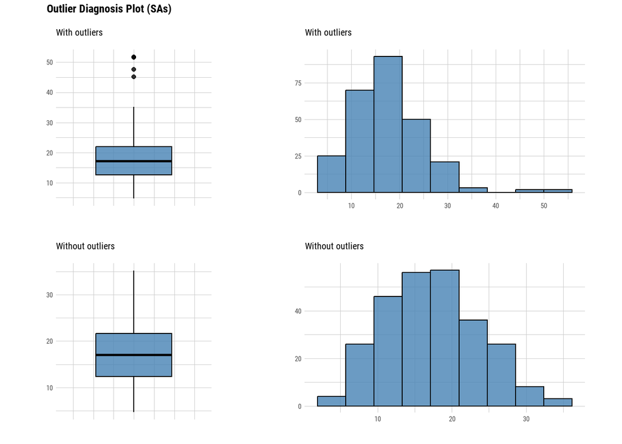

```r
mf.04 %>%
  dlookr::plot_outlier(dlookr::diagnose_outlier(mf.04,SAs) %>%
                 dplyr::filter(outliers_ratio >= 0.5) %>%
                 dplyr::select(variables) %>%
                 unlist())
```

6. Perform a normality test on multiple numerical data (such as GAs,StAs, WAs,SAs, SPAs,SAoAs and SAoFe) using dlookr::normality() function.

```r
mf.04 %>%
  dplyr::select(GAs, StAs, WAs, SAs, SPAs, SAoAs) %>%
  dlookr::normality() %>%
  # sort variables that do not follow a normal distribution in order of p_value:
  dplyr::filter(p_value <= 0.01) %>%
  dplyr::arrange(abs(p_value)) %>%
  flextable()
```

| vars | statistic | p_value | sample |
| --- | --- | --- | --- |
| StAs | 0.9184199 | 0.00000000006628808 | 272 |
| SPAs | 0.9252600 | 0.00000000024891177 | 272 |
| SAs | 0.9303245 | 0.00000000073703281 | 272 |
| GAs | 0.9409366 | 0.00000000712630377 | 272 |
| WAs | 0.9433134 | 0.00000001241526742 | 272 |
| SAoAs | 0.9570003 | 0.00000045042002642 | 272 |

7. Use dlookr::normality() and dplyr::group_by() check normality of rice garin As (GAs) in different rice varieties.

```r
mf.04 %>%
  dplyr::group_by(variety) %>%
  dlookr::normality(GAs) %>%
  dplyr:: arrange(desc(p_value)) %>%
  flextable()
```

| variable | variety | statistic | p_value | sample |
| --- | --- | --- | --- | --- |
| GAs | BR29 | 0.9725804 | 0.91639265557 | 7 |
| GAs | BR28 | 0.9880536 | 0.63603445902 | 84 |
| GAs | Minikate | 0.9316683 | 0.18588001198 | 19 |
| GAs | Ratna | 0.9519449 | 0.14040876714 | 34 |
| GAs | Purbachi | 0.9378160 | 0.02646155958 | 41 |
| GAs | IET | 0.9183203 | 0.00006485247 | 82 |
| GAs |  |  |  | 5 |

8. Plot histogram and QQ-plot of SAs and histogram and square root transformed SAs using dlookr::plot_normality() function

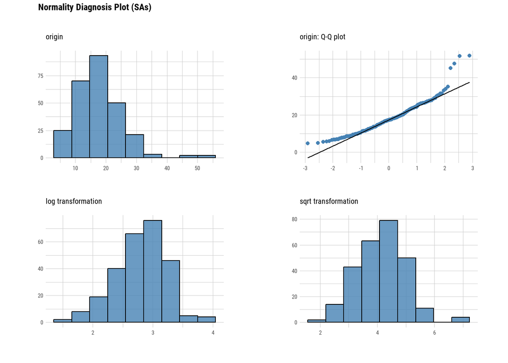

```r
mf.04 %>% dlookr::plot_normality(SAs)
```

9. Create a descriptive statistics table for GAs, StAs, Soil, WAs, PAs using dlookr::describe() and flextable() functions

```r
# First select  numerical columns
des.stata<-mf.04 %>%
  dplyr::select(GAs, StAs, WAs, SAs, SPAs, SAoAs) %>%
 # then descrive them
  dlookr::describe()
flextable(des.stata)
```

| described_variables | n | na | mean | sd | se_mean | IQR | skewness | kurtosis | p00 | p01 | p05 | p10 | p20 | p25 | p30 | p40 | p50 | p60 | p70 | p75 | p80 | p90 | p95 | p99 | p100 |
| --- | --- | --- | --- | --- | --- | --- | --- | --- | --- | --- | --- | --- | --- | --- | --- | --- | --- | --- | --- | --- | --- | --- | --- | --- | --- |
| GAs | 267 | 5 | 0.3235318 | 0.12051750 | 0.007375551 | 0.146 | 1.1144349 | 2.702069 | 0.094 | 0.11922 | 0.1586 | 0.1770 | 0.2262 | 0.2385 | 0.2600 | 0.2902 | 0.312 | 0.3356 | 0.3674 | 0.3845 | 0.4038 | 0.4698 | 0.5214 | 0.72790 | 0.845 |
| StAs | 267 | 5 | 10.2726592 | 5.59591366 | 0.342464354 | 5.650 | 1.2186090 | 1.967379 | 0.900 | 1.60000 | 2.7000 | 4.2600 | 6.1200 | 6.6500 | 7.2800 | 8.1400 | 9.200 | 10.2000 | 11.5200 | 12.3000 | 14.0600 | 17.9000 | 21.7700 | 27.13400 | 34.500 |
| WAs | 267 | 5 | 0.1282097 | 0.07981097 | 0.004884352 | 0.101 | 0.9689059 | 1.445371 | 0.011 | 0.01498 | 0.0200 | 0.0320 | 0.0590 | 0.0735 | 0.0798 | 0.0990 | 0.118 | 0.1362 | 0.1644 | 0.1745 | 0.1838 | 0.2314 | 0.2580 | 0.36814 | 0.458 |
| SAs | 266 | 6 | 17.7991729 | 7.39504618 | 0.453419373 | 9.475 | 1.2210798 | 3.464891 | 4.700 | 5.63000 | 7.8500 | 9.3000 | 11.4000 | 12.5250 | 13.6000 | 15.7000 | 17.200 | 18.6000 | 20.2200 | 22.0000 | 23.5000 | 26.5000 | 29.0000 | 45.97500 | 51.800 |
| SPAs | 267 | 5 | 4.3745655 | 2.23930641 | 0.137043327 | 2.768 | 1.2263919 | 2.767948 | 0.779 | 0.99906 | 1.6500 | 1.8106 | 2.5700 | 2.8040 | 3.0766 | 3.4850 | 4.034 | 4.5182 | 5.1212 | 5.5720 | 6.1966 | 7.2320 | 7.9649 | 11.30860 | 14.804 |
| SAoAs | 265 | 7 | 9.7763283 | 4.55291527 | 0.279683362 | 6.490 | 0.8287728 | 1.118295 | 1.390 | 2.34080 | 3.6000 | 4.4760 | 5.7000 | 6.0600 | 6.4980 | 8.1680 | 9.700 | 10.5480 | 11.6820 | 12.5500 | 13.1680 | 15.6800 | 17.5280 | 23.64192 | 27.869 |

10. Use dlookr::describe() and dplyr::group_by() functions calculate descriptive testatrices of SAs, SPAs, SAoAs and SAoFe in different landtypes

```r
mf.04 %>%
  group_by(land_type) %>%
  dlookr::describe(GAs, StAs, WAs, SAs, SPAs, SAoAs) %>%
  flextable()
```

| described_variables | land_type | n | na | mean | sd | se_mean | IQR | skewness | kurtosis | p00 | p01 | p05 | p10 | p20 | p25 | p30 | p40 | p50 | p60 | p70 | p75 | p80 | p90 | p95 | p99 | p100 |
| --- | --- | --- | --- | --- | --- | --- | --- | --- | --- | --- | --- | --- | --- | --- | --- | --- | --- | --- | --- | --- | --- | --- | --- | --- | --- | --- |
| GAs |  | 0 | 5 |  |  |  |  |  |  |  |  |  |  |  |  |  |  |  |  |  |  |  |  |  |  |  |
| GAs | HL | 126 | 0 | 0.3008492 | 0.12654871 | 0.011273856 | 0.16175 | 1.0530918 | 1.88531696 | 0.094 | 0.09975 | 0.14025 | 0.1620 | 0.1880 | 0.21150 | 0.2275 | 0.256 | 0.2905 | 0.310 | 0.3455 | 0.37325 | 0.3940 | 0.4635 | 0.49850 | 0.65750 | 0.829 |
| GAs | MHL | 141 | 0 | 0.3438014 | 0.11144917 | 0.009385713 | 0.11500 | 1.4825586 | 4.35384480 | 0.151 | 0.15760 | 0.20200 | 0.2240 | 0.2600 | 0.27300 | 0.2890 | 0.311 | 0.3230 | 0.353 | 0.3730 | 0.38800 | 0.4090 | 0.4810 | 0.53100 | 0.76300 | 0.845 |
| SAoAs |  | 0 | 5 |  |  |  |  |  |  |  |  |  |  |  |  |  |  |  |  |  |  |  |  |  |  |  |
| SAoAs | HL | 125 | 1 | 7.8533360 | 3.70137209 | 0.331060784 | 5.05900 | 0.7263991 | 0.02425052 | 1.390 | 2.12552 | 3.16800 | 3.6400 | 4.6720 | 5.14100 | 5.4500 | 6.030 | 6.9600 | 8.380 | 9.7800 | 10.20000 | 10.8260 | 12.7840 | 14.50400 | 17.72680 | 18.700 |
| SAoAs | MHL | 140 | 1 | 11.4932857 | 4.56661109 | 0.385949079 | 5.47475 | 0.8467886 | 1.40063074 | 3.040 | 3.45100 | 4.94770 | 5.9728 | 7.5992 | 8.26650 | 9.0600 | 10.400 | 11.1000 | 12.086 | 13.1120 | 13.74125 | 14.8112 | 16.2880 | 19.71700 | 25.93918 | 27.869 |
| SAs |  | 0 | 5 |  |  |  |  |  |  |  |  |  |  |  |  |  |  |  |  |  |  |  |  |  |  |  |
| SAs | HL | 125 | 1 | 13.9980000 | 5.31966452 | 0.475805260 | 7.50000 | 0.6331716 | 0.05836453 | 4.700 | 4.96800 | 6.72000 | 7.8800 | 9.2800 | 9.70000 | 10.4800 | 11.880 | 13.4000 | 14.940 | 16.5800 | 17.20000 | 18.1620 | 21.2180 | 23.92000 | 27.85200 | 28.200 |
| SAs | MHL | 141 | 0 | 21.1690071 | 7.35606788 | 0.619492670 | 7.60000 | 1.5135072 | 4.39631670 | 5.700 | 9.84000 | 11.60000 | 13.1000 | 15.9000 | 16.80000 | 17.4000 | 18.300 | 20.0000 | 22.400 | 23.8000 | 24.40000 | 26.1000 | 28.7000 | 31.60000 | 50.00000 | 51.800 |
| SPAs |  | 0 | 5 |  |  |  |  |  |  |  |  |  |  |  |  |  |  |  |  |  |  |  |  |  |  |  |
| SPAs | HL | 126 | 0 | 3.2519921 | 1.59920583 | 0.142468578 | 2.03600 | 1.0418655 | 0.79940148 | 0.779 | 0.87750 | 1.44875 | 1.6500 | 1.8270 | 1.89900 | 2.0930 | 2.645 | 3.0065 | 3.340 | 3.6375 | 3.93500 | 4.1390 | 5.5720 | 6.52675 | 7.86500 | 8.265 |
| SPAs | MHL | 141 | 0 | 5.3777163 | 2.25752914 | 0.190118250 | 2.86700 | 1.3078618 | 3.21431460 | 1.030 | 1.59960 | 2.64500 | 3.0710 | 3.6000 | 3.84100 | 4.1350 | 4.514 | 4.9400 | 5.324 | 6.4700 | 6.70800 | 7.1000 | 7.8700 | 9.10400 | 13.67800 | 14.804 |
| StAs |  | 0 | 5 |  |  |  |  |  |  |  |  |  |  |  |  |  |  |  |  |  |  |  |  |  |  |  |
| StAs | HL | 126 | 0 | 9.0015873 | 5.81156067 | 0.517734974 | 5.80000 | 1.5389325 | 3.45524334 | 0.900 | 1.15000 | 1.97500 | 2.7000 | 4.6000 | 5.27500 | 5.9000 | 7.200 | 8.0500 | 8.900 | 10.0500 | 11.07500 | 12.1000 | 16.3000 | 19.07500 | 27.15000 | 34.500 |
| StAs | MHL | 141 | 0 | 11.4085106 | 5.15636208 | 0.434244023 | 5.90000 | 1.1988516 | 1.19295583 | 2.700 | 4.00000 | 5.90000 | 6.2000 | 7.3000 | 7.60000 | 8.0000 | 9.400 | 10.2000 | 10.900 | 12.3000 | 13.50000 | 15.0000 | 18.7000 | 22.50000 | 26.74000 | 28.100 |
| WAs |  | 0 | 5 |  |  |  |  |  |  |  |  |  |  |  |  |  |  |  |  |  |  |  |  |  |  |  |
| WAs | HL | 126 | 0 | 0.1098571 | 0.07783765 | 0.006934329 | 0.13675 | 0.8428157 | 1.61866254 | 0.011 | 0.01225 | 0.01625 | 0.0195 | 0.0310 | 0.03725 | 0.0435 | 0.074 | 0.1105 | 0.126 | 0.1605 | 0.17400 | 0.1810 | 0.2035 | 0.22525 | 0.27075 | 0.458 |
| WAs | MHL | 141 | 0 | 0.1446099 | 0.07822420 | 0.006587666 | 0.08500 | 1.2239183 | 1.33433339 | 0.032 | 0.03660 | 0.05300 | 0.0640 | 0.0820 | 0.09200 | 0.0970 | 0.107 | 0.1220 | 0.145 | 0.1660 | 0.17700 | 0.2000 | 0.2520 | 0.30600 | 0.37360 | 0.427 |

11. Calculates the correlation coefficient of all combinations of WAs, WFe, WP, WEc, SEc, SAs, SPAs, SAoAs and SAoFe and plot them using dlookr::correlate() and plot() functions.

```r
# First select  numerical columns
mf.04 %>%
  dplyr::select(GAs, StAs, WAs, SAs, SPAs, SAoAs) %>%
# then diagnose them
  dlookr::correlate()%>%
  flextable()
```

| var1 | var2 | coef_corr |
| --- | --- | --- |
| StAs | GAs | 0.5353603 |
| WAs | GAs | 0.3429053 |
| SAs | GAs | 0.2989951 |
| SPAs | GAs | 0.3196658 |
| SAoAs | GAs | 0.2283496 |
| GAs | StAs | 0.5353603 |
| WAs | StAs | 0.2341373 |
| SAs | StAs | 0.3240322 |
| SPAs | StAs | 0.3399112 |
| SAoAs | StAs | 0.2316530 |
| GAs | WAs | 0.3429053 |
| StAs | WAs | 0.2341373 |
| SAs | WAs | 0.2471720 |
| SPAs | WAs | 0.2974873 |
| SAoAs | WAs | 0.2782186 |
| GAs | SAs | 0.2989951 |
| StAs | SAs | 0.3240322 |
| WAs | SAs | 0.2471720 |
| SPAs | SAs | 0.8897471 |
| SAoAs | SAs | 0.8877485 |
| GAs | SPAs | 0.3196658 |
| StAs | SPAs | 0.3399112 |
| WAs | SPAs | 0.2974873 |
| SAs | SPAs | 0.8897471 |
| SAoAs | SPAs | 0.8490460 |
| GAs | SAoAs | 0.2283496 |
| StAs | SAoAs | 0.2316530 |
| WAs | SAoAs | 0.2782186 |
| SAs | SAoAs | 0.8877485 |
| SPAs | SAoAs | 0.8490460 |

12. Calculates the correlation coefficients in two landtypes: use dlookr::correlate() and dplyr::group_by()

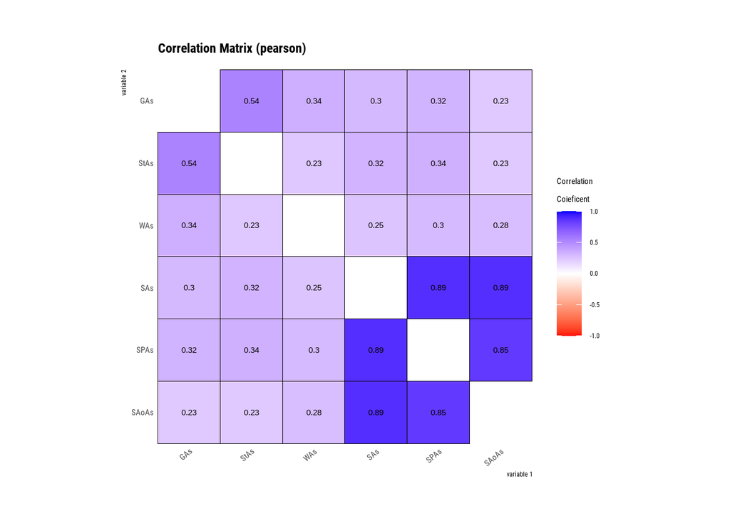

```r
mf.04 %>%
  dplyr::select(GAs, StAs, WAs, SAs, SPAs, SAoAs) %>%
# then diagnose them
  dlookr::correlate()%>%
  plot()
```

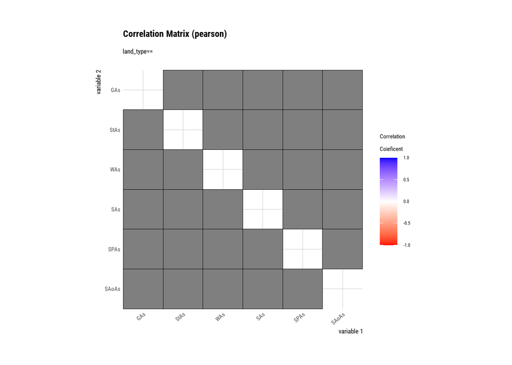

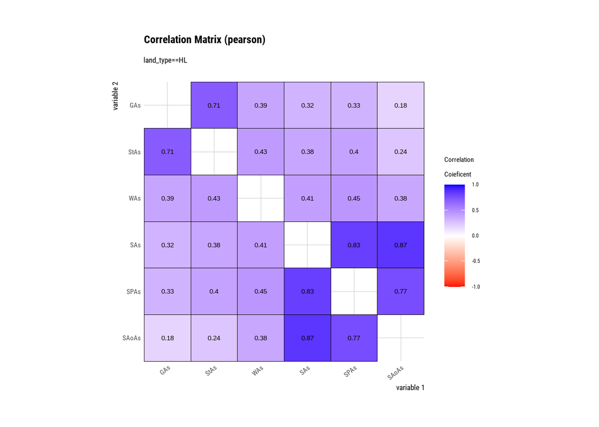

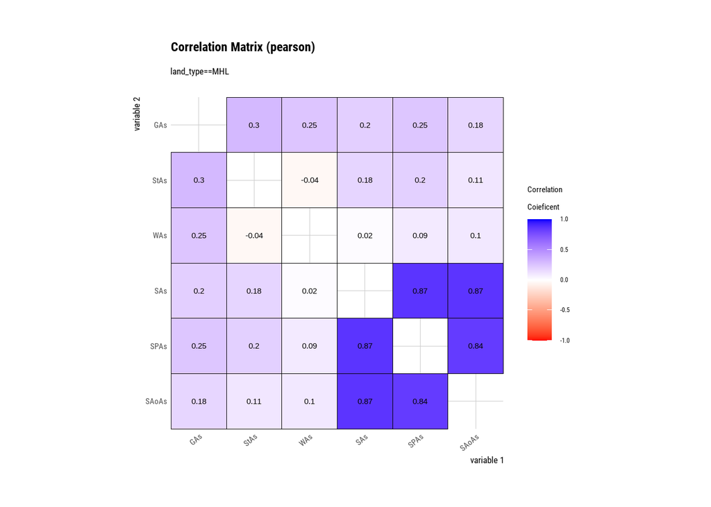

```r
mf.04 %>%
  group_by(land_type) %>%
  dplyr::select(GAs, StAs, WAs, SAs, SPAs, SAoAs) %>%
# then diagnose them
  dlookr::correlate()%>%
  plot()
```